# Índice de marginación (CONAPO)

Pedro Alan Velázquez Romero

4/16/2020

## Introducción

La CONAPO (Comisión Nacional de Población) es un conszejo gubernamental cuya misión es la planeación demográfica del país a fin de incluir a la población en los programas de desarrollo económico y social que se formulen dentro del sector gubernamental y vincular sus objetivos a las necesidades que plantean los fenómenos demográficos. Una de sus funciones es medir el índice de marginación del país cada 5 años a partir de 1990. El conjunto de datos se puede descargar [aquí](http://www.conapo.gob.mx/es/CONAPO/Datos_Abiertos_del_Indice_de_Marginacion).

Una pregunta interesante sería saber si podemos lograr hacer un algoritmo en el cual podamos clasificar los municipios según ciertos criterios, ya sea especificados por la misma CONAPO, o, por alguna otra persona que quiera realizar investigación acerca de esto. La ventaja que nos podría dar la agrupación sería un manejo más fácil de los datos en un futuro o poder hacer inferencia para poder llegar a hacer incluso políticas públicas, económicas, etc.

Para empezar, se cuenta con una base de datos con la versión del año 1990 con un total de 2403 instancias o “muestras”, a partir de aquí, para poder hacer más amigables las resoluciones gráficas y manejar más fácil la información, se tomó una muestra de 800 datos tomando la semilla 156113.

Primero leamos el archivo y veamos una vista rápida del conjunto de datos.

```r
#leemos el archivo
marginacion <- read.csv("/Users/pedrovela/Downloads/marginacion_conapo/1990marginacion.csv")
summary(marginacion)
```

```
##                               ENT          CVE_MUN                 MUN
##  Oaxaca                         : 570   Min.   : 1001   Ocampo       :   6
##  Puebla                         : 217   1st Qu.:14090   Benito Ju·rez:   5
##  Veracruz de Ignacio de la Llave: 207   Median :20228   Hidalgo      :   5
##  Jalisco                        : 124   Mean   :19362   Ju·rez       :   5
##  MÈxico                         : 121   3rd Qu.:24016   Morelos      :   5
##  Michoac·n de Ocampo            : 113   Max.   :32056   Villa Hidalgo:   5
##  (Other)                        :1051                   (Other)      :2372
##     POB_TOT            ANALF           SPRIM           OVSDE
##  Min.   :    149   Min.   : 1.67   Min.   : 8.11   Min.   : 0.30
##  1st Qu.:   3829   1st Qu.:11.93   1st Qu.:46.78   1st Qu.:21.55
##  Median :  10844   Median :20.28   Median :58.55   Median :40.91
##  Mean   :  33812   Mean   :23.03   Mean   :57.24   Mean   :42.37
##  3rd Qu.:  25918   3rd Qu.:30.41   3rd Qu.:68.59   3rd Qu.:62.05
##  Max.   :1650205   Max.   :86.07   Max.   :98.55   Max.   :99.64
##
##      OVSEE            OVSAE             VHAC             OVPT
##  Min.   :  0.00   Min.   :  0.00   Min.   : 21.74   Min.   :  0.10
##  1st Qu.:  6.98   1st Qu.: 12.99   1st Qu.: 58.93   1st Qu.: 18.46
##  Median : 15.43   Median : 28.83   Median : 67.68   Median : 35.94
##  Mean   : 23.81   Mean   : 34.48   Mean   : 66.70   Mean   : 41.30
##  3rd Qu.: 34.90   3rd Qu.: 51.59   3rd Qu.: 75.47   3rd Qu.: 61.20
##  Max.   :100.00   Max.   :100.00   Max.   :100.00   Max.   :100.00
##
##     PL.5000           PO2SM              IM                    GM
##  Min.   :  0.00   Min.   : 27.05   Min.   :-2.6780000   Alto    :812
##  1st Qu.: 52.16   1st Qu.: 68.09   1st Qu.:-0.7640000   Bajo    :656
##  Median :100.00   Median : 79.08   Median :-0.0150000   Medio   :462
##  Mean   : 77.02   Mean   : 77.19   Mean   : 0.0000008   Muy alto:341
##  3rd Qu.:100.00   3rd Qu.: 87.86   3rd Qu.: 0.7140000   Muy bajo:132
##  Max.   :100.00   Max.   :100.00   Max.   : 2.7650000
##
##     LUG_NAC         LUGAR_EST          AÑO
##  Min.   :   1.0   Min.   :  1.0   Min.   :1990
##  1st Qu.: 601.5   1st Qu.: 23.0   1st Qu.:1990
##  Median :1202.0   Median : 56.0   Median :1990
##  Mean   :1202.0   Mean   :109.5   Mean   :1990
##  3rd Qu.:1802.5   3rd Qu.:131.5   3rd Qu.:1990
##  Max.   :2403.0   Max.   :570.0   Max.   :1990
##
```

```r
set.seed(156113)
marg <- sample_n(marginacion,800)
```

Ahora, lo que nos proponemos hacer es un análisis exploratorio en donde podramos obtener una descripción de los datos y, por otro lado, un análisis predictivo con el fin de poder predecir que grado de marginación obtendrá alguna entidad federativa del país con base en algunas variables cuantitativas.

## Análisis exploratorio

Para empezar, observemos la frecuencia de los datos en cuanto al grado de marginación.

```r
(counts_local <- table(marg$GM))
```

```
##
##     Alto     Bajo    Medio Muy alto Muy bajo
##      275      221      160       99       45
```

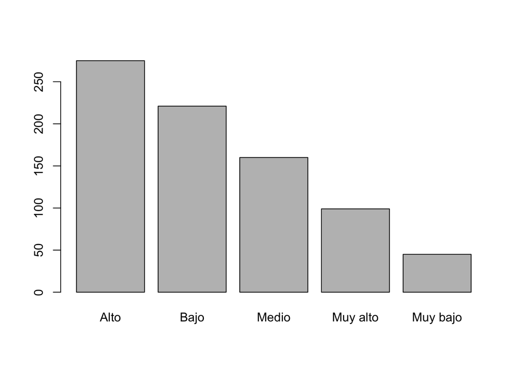

```r
barplot(counts_local)
```

De aquí vemos que la mayoría de las entidades tienen grado alto de marginación (para ser exactos 275 entidades tienen este índice) y el segundo grado con más frecuencia es bajo con 221. Un resultado interesante acerca de esta primera vista es que los grados “extremos”, es decir, muy altos y muy bajos, son los que presentan menos frecuencia de entidades con 99 y 45 respectivamente, esto nos dice que en todo el país casi no hay entidades federativas que vivan en situaciones extremas, es decir, no somos un país “extremo”.

Ahora, analizaremos las características de estos niveles de marginación con respecto a algunas variables cuantitativas. Para empezar, analizaremos las variables ANALF y SPRIM las cuales miden el porcentaje de población de 15 años o más analfabeta y el porcentaje de población de 15 años o más sin primaria completa respectivamente. Se escogieron estas variables porque podemos pensar que están muy correlacionadas.

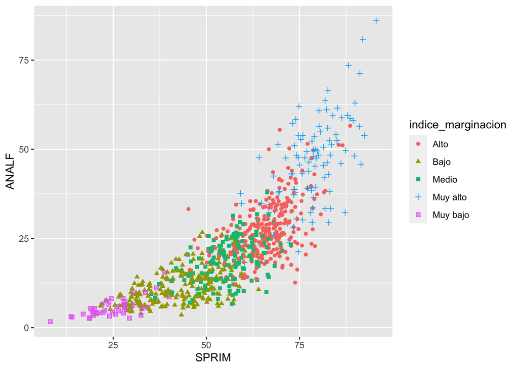

```r
indice_marginacion <- as.factor(marg$GM)
ggplot(marg, aes(SPRIM, ANALF, shape=indice_marginacion,color=indice_marginacion)) + geom_point()
```

Al ver la gráfica vemos que hay dos grados de marginación que se separan de los demás, muy bajo y muy alto, para el caso del grado muy bajo vemos que presenta niveles muy bajos tanto de analfabetismo y de primaria trunca, mientras que el grado muy alto presenta niveles muy altos de analfabetismo y de primaria trunca. Esto solo nos confirma lo que hubiésemos pensado con el sentido común, que entidades con marginación muy alta tienen niveles de educación muy bajas o nulas, mientras que aquellas entidades con muy poca marginación presentan niveles educativos altos.

Los otros grados de marginación parecen estar muy entre mnezclados y parace que no hay una separación clara entre ellos, lo cual nos hace pensar que podríamos dividir los datos en tres grupos excluyentes entre sí. Al final podemos ver que si existe una correlación positiva entre ambas variables, es decir, mientras más primaria trunca haya, más analfabetismo resulta.

Ahora haremos un análisis parecido pero ahora con las variables PO2SM y VHAC las cuales miden el porcentaje de población ocupada con ingresos de hasta 2 salarios mínimos y el porcentaje de viviendas con algún nivel de hacinamiento respectivamente, estas variables parecen estar igualmente correlacionadas.

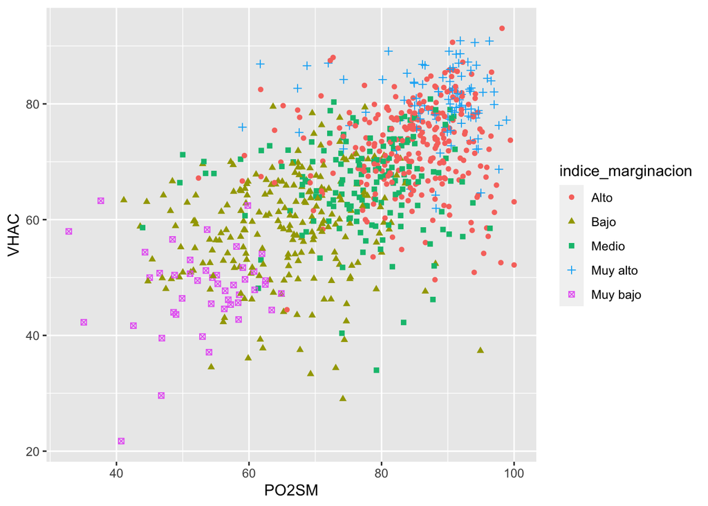

```r
ggplot(marg, aes(PO2SM, VHAC, shape=indice_marginacion,color=indice_marginacion)) + geom_point()
```

Primero, vemos que al parecer si existe una correlación posirtiva entre las variables, es decir, entre más gente hay con hasta dos salarios mínimos, más niveles de hacinamiento presenta. Después, vemos que prácticamente todos los grados están entre mezclados, solo parece que los grados muy bajo y bajo son los que despegan al presentar niveles más bajos hacinamiento y de personas con hasta 2 salarios mínimos, lo cual, a su vez, coincide una vez más con el sentido común al pensar que aquellas entidades con niveles muy bajas de marginación son las que ganan más dinero y por lo tanto pueden comprar casas más grandes y evitar el hacinamiento.

Hasta ahora, hemos detectado ya algunas características de los grados de marginación con base en algunas variables cuantitativas, por ejemplo, que el grado muy bajo de marginación presenta niveles bajos de hacinamiento, analafabetismo, primaria trunca y salario bajo; de aquí podemos empezar ya a clasificar entidades nuevas si es que detectamos este tipo de niveles en sus variables.

Ahora, empezaremos con análisis estadístico un poco más complejo, para ser exactos, empezaremos con un análisis de clasificación para ver si es que podemos separar los datos en $k$ grupos diferentes con una separación lo más exacta posible; después haremos un análisis de tipo predictivo mediante un análisis de discriminante lineal.

## Clusterización

La estrategia por realizar es la siguiente: primero se desechan las variables que no sean cuantitativas para después a escalar las variables para que la información se presente de una manera más limpia. Después, se decidió que se haría pca, esto porque queremos disminuir la dimensión de nuestros datos tomando las componentes con mayor varianza explicativa y para posteriormente formar los grupos como tal.

Para empezar, con la ayuda de la función *fviz_nbclust* de *R* obtenemos el número óptimo de clusters mediante la “técnica del codo”.

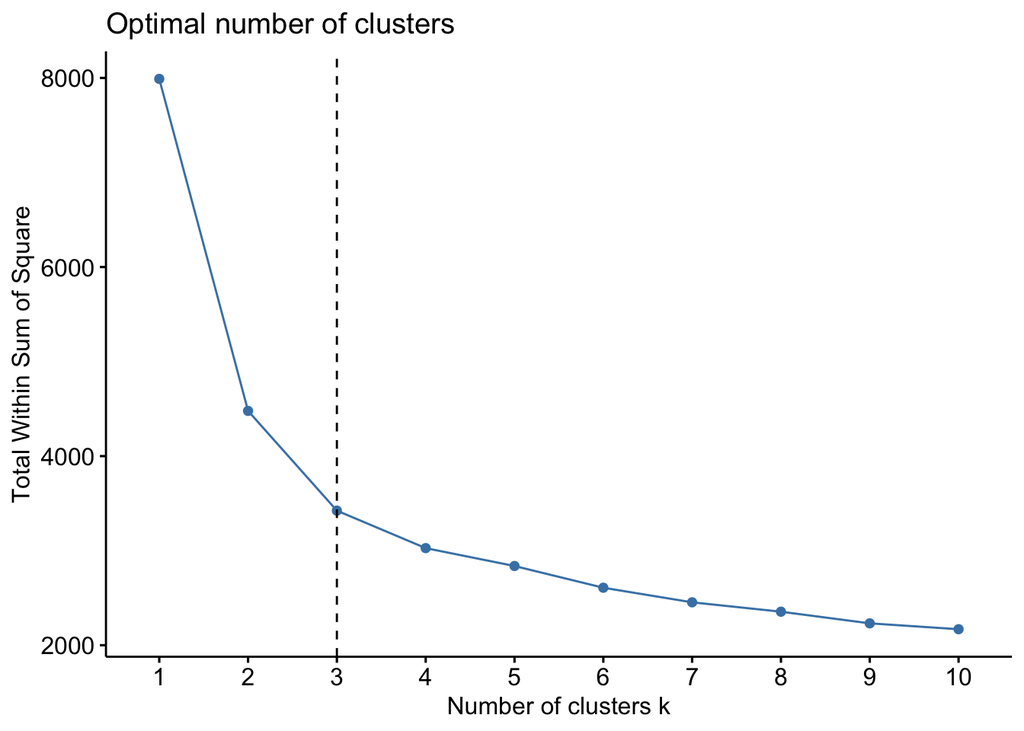

```r
#Quitamos la columna de las clases y escalamos las variables
marg.scaled <- scale(marg[,c(-1,-2,-15,-18,-17,-3,-4,-16)])
#Hacemos la gráfica donde vemos el número óptimo de clusters
fviz_nbclust(marg.scaled, kmeans, method = "wss") + geom_vline(xintercept = 3, linetype = 2)
```

De esta gráfica vemos que el número óptimo den clusters es 3 (algo que habíamos previsto desde el análisis exploratorio). Procedemos a hacer PCA:

```r
#Corremos la función
marg.pca <- prcomp(marg.num,center = TRUE,scale. = TRUE)
summary(marg.pca)
```

```
## Importance of components:
##                          PC1     PC2     PC3     PC4     PC5     PC6    PC7
## Standard deviation     2.569 0.90266 0.82348 0.72004 0.62717 0.56487 0.5514
## Proportion of Variance 0.660 0.08148 0.06781 0.05185 0.03933 0.03191 0.0304
## Cumulative Proportion  0.660 0.74152 0.80934 0.86118 0.90052 0.93243 0.9628
##                            PC8     PC9      PC10
## Standard deviation     0.50131 0.34705 0.0002749
## Proportion of Variance 0.02513 0.01204 0.0000000
## Cumulative Proportion  0.98796 1.00000 1.0000000
```

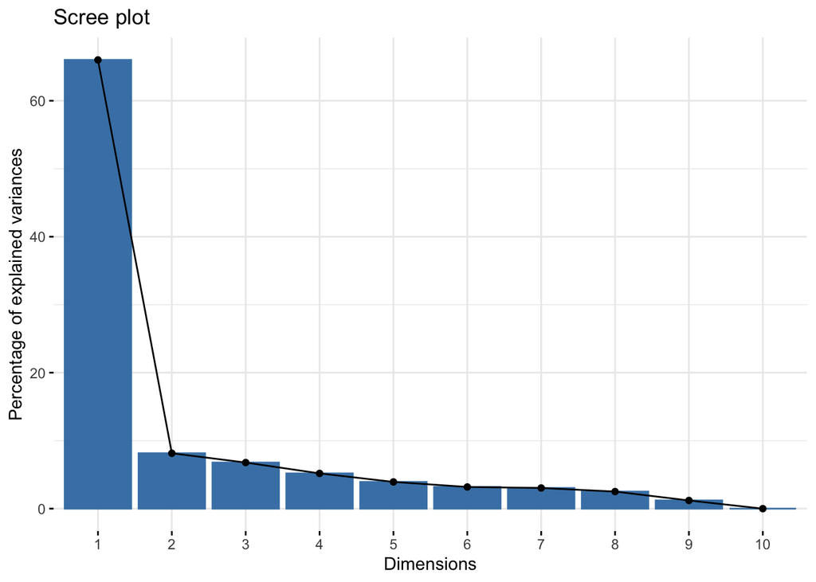

```r
#Ploteamos
fviz_eig(marg.pca)
```

Del primer resultado del análisis por componentes principales vemos que ya con las primeras dos componentes principales explicamos prácticamente el 75% de la variación de los datos y ya con las tres primeras componentes ya explicamos el 80%, es decir, ya con muy pocas dimensiones podemos explicar bastante bien al conjunto de datos. Pero echemos un vistazo qué valores exactamente presentan las dos primeras componentes principales:

```r
marg.pca
```

```
## Standard deviations (1, .., p=10):
##  [1] 2.5691314659 0.9026642189 0.8234819680 0.7200434960 0.6271709031
##  [6] 0.5648739025 0.5513580129 0.5013078687 0.3470510774 0.0002749263
##
## Rotation (n x k) = (10 x 10):
##               PC1          PC2           PC3          PC4          PC5
## ANALF   0.3364942  0.143000910 -0.2506883740  0.325277904 -0.320256611
## SPRIM   0.3509812 -0.116481597 -0.0362965575  0.195172661 -0.184729397
## OVSDE   0.3191526 -0.115571841 -0.0003379485 -0.314791879 -0.591072139
## OVSEE   0.2718370  0.495439910  0.4686779456  0.316181437  0.254020758
## OVSAE   0.2772401  0.407685732  0.2212596640 -0.715314684  0.101902862
## VHAC    0.2994948  0.064177060 -0.5861485212 -0.150328972  0.162587696
## OVPT    0.3360713  0.127913728 -0.0387974959  0.331838736  0.126504097
## PL.5000 0.2602295 -0.576708689  0.5462578318  0.011229550 -0.058516514
## PO2SM   0.2985050 -0.433451029 -0.1540933534 -0.111854839  0.627030643
## IM      0.3892329 -0.002059712  0.0022834746 -0.002972725  0.002021473
##                  PC6          PC7           PC8          PC9       PC10
## ANALF   -0.297886446  0.222043614 -0.1247529149 -0.650410767 -0.1359064
## SPRIM   -0.257247415  0.194310192 -0.4723953710  0.664046173 -0.1471805
## OVSDE    0.567634912  0.175135654  0.2485086891  0.054203204 -0.1369234
## OVSEE    0.474695678 -0.022670147 -0.2332743610 -0.054368553 -0.1151733
## OVSAE   -0.409041853  0.063072272  0.0008573797 -0.026780003 -0.1179147
## VHAC     0.189860410 -0.647057670 -0.2065927962 -0.001923893 -0.1271440
## OVPT    -0.207227147 -0.122588284  0.7743137736  0.255057716 -0.1431133
## PL.5000 -0.161243559 -0.457512462 -0.0501951094 -0.217570256 -0.1120994
## PO2SM    0.158839335  0.484502950  0.0183903509 -0.130363551 -0.1276142
## IM       0.002707325 -0.001833446  0.0022214925  0.002794040  0.9211145
```

Aquí vemos que, por ejemplo, en la combinación lineal para PC1, se tienen valores positivos de las constantes de las variables y son similares entre ellas, entonces, aquellas entidades que pertenezcan a la primera componente presentan valores altos de las variables y positivas, una forma más de clasificar a los datos. Ahora veamos las gráficas de los datos para representar estos números.

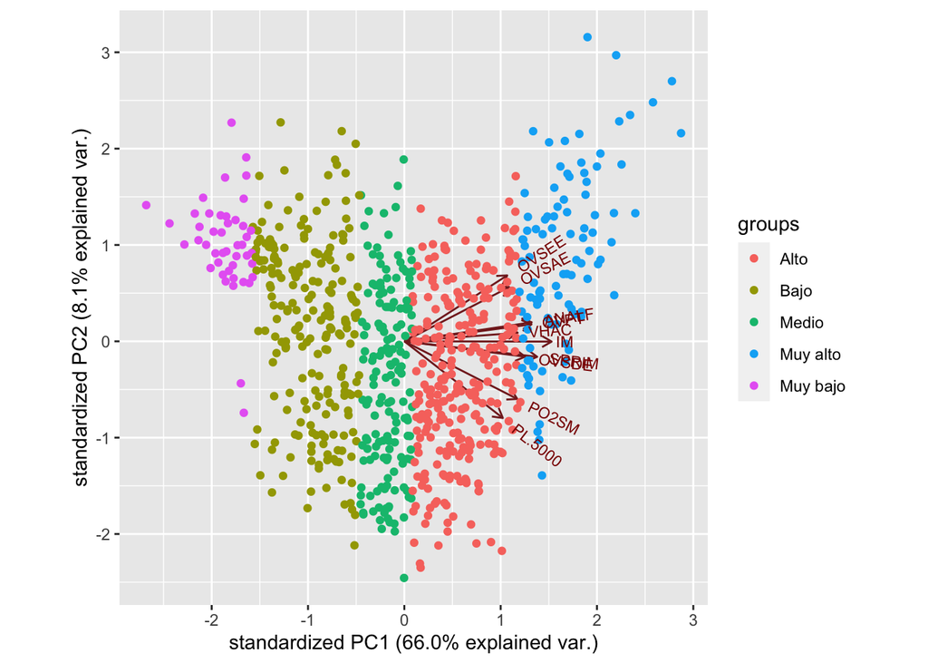

```r
ggbiplot(marg.pca,ellipse = FALSE,groups = marg$GM)
```

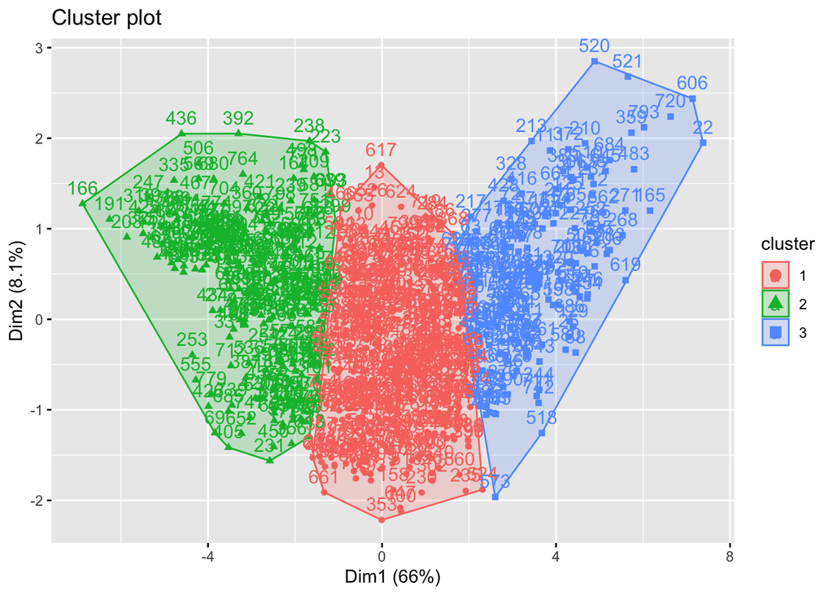

```r
#Corremos kmeans
km.marg <- kmeans(marg.pca$x[,1:2],3,nstart = 10)
#Generamos gráficas de elipses con los grupos establecidos
fviz_cluster(km.marg, marg.num)
```

Ya con los dos componentes principales obtenemos una separación en 3 grupos prácticamente perfecta, podemos discernir muy bien la separación entre grupos y así identificar tres grados de marginación y no cinco como al principio lo planteó la CONAPO. De aquí vemos, por ejemplo, que aquellas entidades que presentan valores altos tanto de PC1 como de PC2 pertenecen al grupo 3, mientras que aquellos que presentan niveles bajos de PC1 y medios de PC2 pertenecen al grupo 2, el grupo 1 tiene valores medios tanto de PC1 y PC2. Aquí, ya encontramos una clasificación de las entidades federativas según los valores de sus variables y así asignarles un grado de marginación a cada uno.

## Análisis predictivo

Finalmente, empezaremos con el análisis predictivo, para esto se tomará la técnica de LDA (Linear Discriminant Analysis), se decidió hacerlo con esta técnica ya que este método explica bastante bien la relación que tienen las variables independientes con la variable dependiente (en este caso es el grado de marginación). Para esto, empezaremos separando nuestros datos en dos conjuntos: el conjunto de entrenamiento (train) el cual nos servirá para construir el modelo para así poder crear futuras predicciones; y el otro conjunto de prueba (test) que nos servirá para probar el modelo anteriormente entrenado y así poder verificar la precisión de nuestra predicción. Para este ejercicio hicimos una separación del 70% de los datos para el conjunto de entrenamiento y de un 30% para el conjunto de prueba.

```r
#Empezamos a dividir los archivos en train y test
marg.grado <- marg[,c(-1,-2,-16,-18,-17,-3,-4,-14)]
training_sample_marg <- sample(c(TRUE, FALSE), nrow(marg.grado), replace = T, prob = c(0.7,0.3))
marg.train <- marg.grado[training_sample_marg, ]
marg.test <- marg.grado[!training_sample_marg, ]
```

Empezaremos a correr la función LDA

```r
#Corremos lda
marg.lda <- lda(marg.train$GM ~ ., marg.train)
marg.lda #show results
```

```
## Call:
## lda(marg.train$GM ~ ., data = marg.train)
##
## Prior probabilities of groups:
##       Alto       Bajo      Medio   Muy alto   Muy bajo
## 0.33510638 0.29078014 0.20390071 0.11524823 0.05496454
##
## Group means:
##              ANALF    SPRIM     OVSDE     OVSEE     OVSAE     VHAC      OVPT
## Alto     27.419312 65.82286 54.439206 26.797831 43.641058 72.04741 52.009841
## Bajo     11.593659 43.67982 20.786098 10.218476 17.260610 58.55488 18.421098
## Medio    19.102783 55.54452 40.256087 16.980696 28.187391 65.59887 32.248087
## Muy alto 46.712308 77.66123 72.723846 60.422615 63.137538 79.76646 84.982154
## Muy bajo  5.387419 25.34677  5.988065  3.873548  5.912581 46.69516  5.938065
##           PL.5000    PO2SM
## Alto     93.94508 84.51598
## Bajo     52.90463 66.64726
## Medio    74.86487 77.24696
## Muy alto 99.47138 88.80862
## Muy bajo 11.86935 52.47419
##
## Coefficients of linear discriminants:
##                 LD1          LD2          LD3         LD4
## ANALF   -0.03707484  0.090643038 -0.013311787  0.03513791
## SPRIM   -0.03550856 -0.076358683 -0.030208114 -0.01148981
## OVSDE   -0.02420727  0.002413271  0.034714568  0.03673586
## OVSEE   -0.01630136  0.032146706 -0.041296076  0.01902912
## OVSAE   -0.01782046 -0.001156079  0.019511450 -0.02600747
## VHAC    -0.03373532 -0.045574548 -0.064311482 -0.01782052
## OVPT    -0.01896617  0.020526695  0.036265874 -0.03826392
## PL.5000 -0.01442952 -0.011919837 -0.008724629 -0.01367022
## PO2SM   -0.03575864 -0.027853524  0.011683494  0.05199150
##
## Proportion of trace:
##    LD1    LD2    LD3    LD4
## 0.9407 0.0553 0.0029 0.0011
```

La matriz de confusión resultante es la siguiente:

```r
#Predecimos con test
marg.lda.test <- predict(marg.lda,marg.test)
marg.test$lda <- marg.lda.test$class
(matriz <- table(marg.test$lda,marg.test$GM))
```

```
##
##            Alto Bajo Medio Muy alto Muy bajo
##   Alto       77    0     0        6        0
##   Bajo        0   52     1        0        1
##   Medio       5    3    44        0        0
##   Muy alto    4    0     0       28        0
##   Muy bajo    0    2     0        0       13
```

Los resultados que obtuvimos son muy buenos, ya que, a simple vista, podemos ver que hay pocos valores fuera de la diagonal de la matriz, la cual nos indica que hubo poquitas entidades a las cuales les asignamos un grado de marginación erróneo. Para ser más precisos, los porcentajes de precisión (aproximados) para cada grado de marginación son los siguientes:

- Alto: 92.77%
- Bajo: 96.3%
- Medio: 84.62%
- Muy alto: 87.5%
- Muy bajo: 86.67%

Con esto, obtuvimos una precisión promedio (aproximado) del 89.57% lo cual es bastante bueno y podemos decir que nuestro modelo predice muy bien el grado de marginación de una entidad federativa del país.

## Conclusión

Después de un análisis de los datos pudimos identificar algunas características principales de los grados de marginación para clasificación de los datos. También identificamos que podemos, mediante PCA y kmeans, hacer tres grupos de los datos “perfectos” en el sentido de que cada grupo es independiente del otro y se pueden separar mediante una línea recta. Con estos dos atributos podemos clasificar nuevas entidades federativas en algún grado de marginación según los datos de sus variables cuantitativas.

Al final, realizamos un análisis predictivo mediante la técnica del discriminante lineal con el fin de crear un modelo que nos permita predecir el grado de marginación de una entidad nueva basada en los valores de sus variables cuantitativas. El modelo resultante fue un modelo con una precisión promedio cercana al 90% lo cual nos dice que es un modelo muy bueno y se podría utilizar para futuros datos.